# Mood Disorder & Suicidality Risk Group Cluster Characterizations

Sam A. Sievertsen

2025-01-21

## Review of Clustering Results and Selection of Optimal *k*

Results from the `risk_group_clustering` script suggest it is likely that optimal *k* = 5. Re-iterating the most important information here, this determination was made because the elbow plot suggests a natural elbow wherein reduction in total within sum of squares values levels off after *k* = 5 (*note*: a similar tapering is observed after *k* = 6, but the distinction between the two *k* values will be made in the discussion of the silhouette index results):

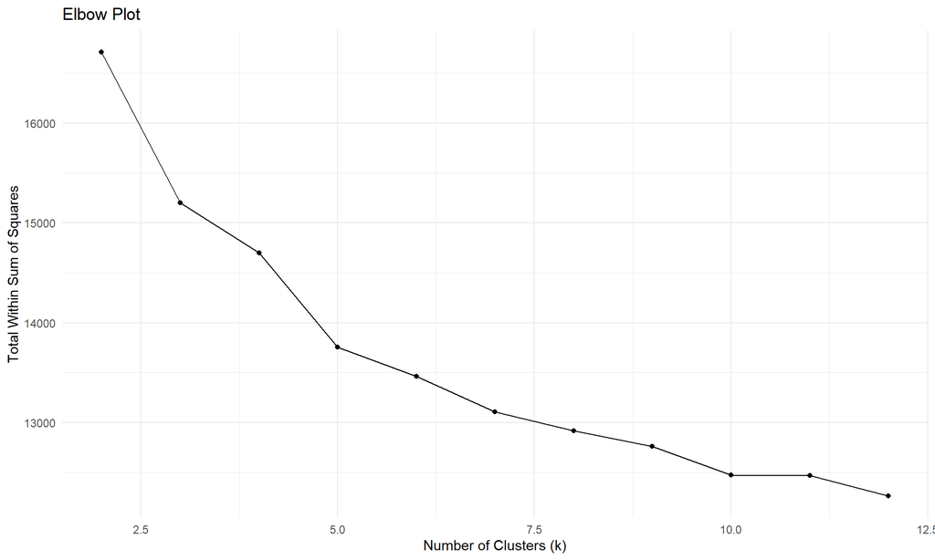

| k | Mean Silhouette Score |
| --- | --- |
| 2 | 0.31955406 |
| 3 | 0.29953326 |
| 4 | 0.14629194 |
| 5 | 0.18245488 |
| 6 | 0.18756773 |
| 7 | 0.12530268 |
| 8 | 0.14201985 |
| 9 | 0.12606615 |
| 10 | 0.12137141 |
| 11 | 0.12255394 |
| 12 | 0.09918380 |

At this point, despite the slightly greater reduction in total within sum of squares values, it is not evident whether *k = 5* is more optimal than *k = 6*. This becomes more clear, though, when we examine the density plot of silhouette scores at the individual subject within-cluster level:

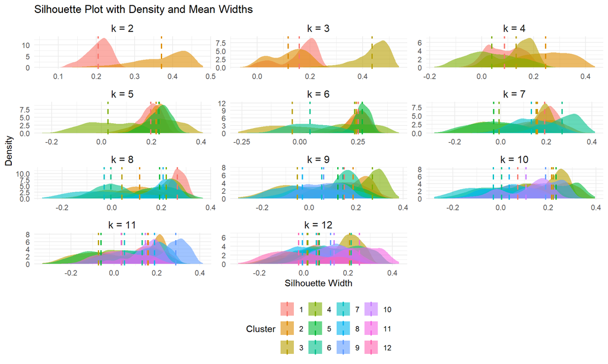

At *k = 5*, the tight grouping of clusters about silhouette = 0.20 for clusters 1, 2, 3, and 5 and relatively good (albeit lower and more spread) performance of cluster 4 (about silhouette = 0.05) is vastly superior to *k = 6*.

At *k = 6*, clusters 1, 2, 4, and 5 perform well (i.e., are grouped about silhouette = 0.25), but clusters 3 and 6 perform worse than cluster 4 in the *k = 5* solution, with cluster 3 actually mean centered below 0 (indicating that most subjects in that cluster would have been more accurately grouped into another cluster).

As such, when considering the results of both the elbow plot and silhouette index, it is likely that optimal *k* = 5.

## Characterization of *k* = 5 Clusters

### Integration of Clusters Back Into Risk Variable Data

In order to best characterize the risk groups (i.e., according to their original risk variables on their native scale), we will first need to merge the clustered group values back into the original risk data:

```r
## Merge Cluster Group Values Back Into Original Data ##

#1. Extract the cluster assignment values from the kproto results
#1.1 Create a dataframe containing each subjects cluster value
subject_cluster_values <- as.data.frame(kproto_results[["k_5"]][["model"]][["cluster"]])

#1.2 Create a column containing each subjects ID
subject_cluster_values$src_subject_id <- row.names(subject_cluster_values)

#1.3 Clean the column names + retain columns of interest
subject_cluster_values <- subject_cluster_values %>%
  mutate(cluster = `kproto_results[["k_5"]][["model"]][["cluster"]]`) %>%
  dplyr::select(c(src_subject_id, cluster))

#2. Merge cluster values back into original data
clustered_risk_variable_data <- left_join(risk_variable_data, subject_cluster_values)
```

### Profiling the Risk Group Clusters According to Risk Variables

Now that cluster assignments have been merged into the original risk data, we can profile the different clusters according to each categorical (binary) risk variable:

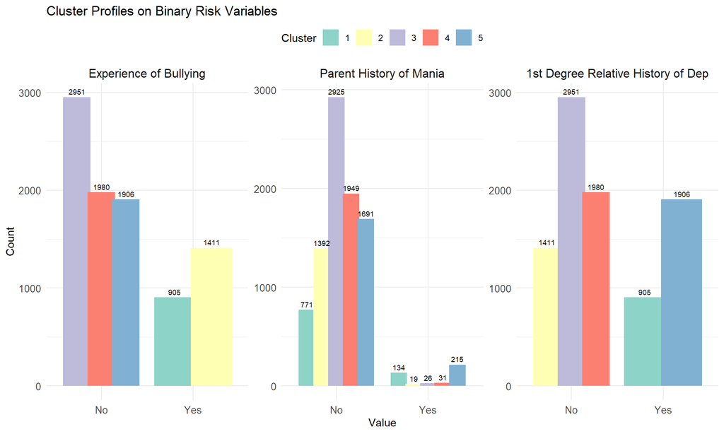

```r
## Characterize the Clusters According to Binary Risk Variables ##

#1. Create a bar chart for each binary variable
#1.1 Define the binary variables
binary_vars <- c("family_history_depression", "famhx_ss_momdad_ma_p", "bullying")

#1.2 Define variable descriptions
binary_variable_labels <- c(
  family_history_depression = "1st Degree Relative History of Dep",
  famhx_ss_momdad_ma_p = "Parent History of Mania",
  bullying = "Experience of Bullying"
)

#1.3 Wrangle data for plotting
binary_plot_data <- clustered_risk_variable_data %>%
  dplyr::select(cluster, family_history_depression, famhx_ss_momdad_ma_p, bullying) %>%
  pivot_longer(-cluster, names_to = "variable", values_to = "value") %>%
  group_by(cluster, variable, value) %>%
  summarise(count = n(), .groups = "drop")

#1.4 Create the binary variable plot
binary_plot <- binary_plot_data %>%
  ggplot(aes(x = as.factor(value), y = count, fill = as.factor(cluster))) +
  geom_bar(stat = "identity", position = position_dodge(width = 0.8)) +
  geom_text(aes(label = count),
            position = position_dodge(width = 0.8),
            vjust = -0.5,
            size = 2.5) +
  facet_wrap(
    ~variable,
    scales = "free_y",
    labeller = as_labeller(binary_variable_labels)
  ) +
  labs(x = "Value", y = "Count", fill = "Cluster",
       title = "Cluster Profiles on Binary Risk Variables") +
  scale_x_discrete(labels = c("0" = "No", "1" = "Yes")) +
  theme_minimal() +
  theme(strip.text = element_text(size = 12),
        axis.text = element_text(size = 10),
        legend.position = "top") +
  scale_fill_brewer(palette = "Set3")

#1.4 Print the binary values plot
print(binary_plot)
```

As well as profile the clusters according to each continuous risk variable:

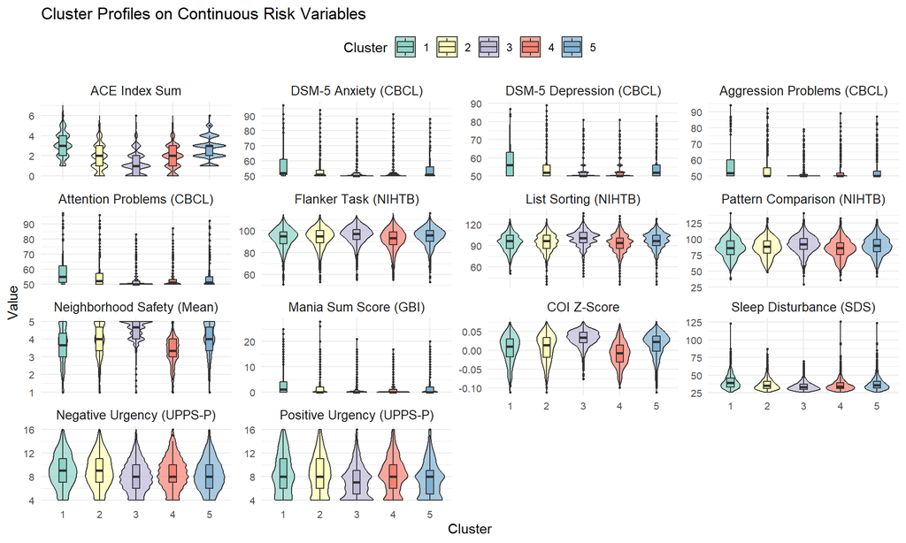

```r
## Characterize the Clusters According to Continuous Risk Variables ##

#1. Create a violin boxplot for each continuous variable
#1.1 Define the continuous variables and descriptions
continuous_vars <- c("cbcl_scr_dsm5_depress_t", "cbcl_scr_dsm5_anxdisord_t",
                     "cbcl_scr_syn_attention_t", "cbcl_scr_syn_aggressive_t",
                     "pgbi_p_ss_score", "upps_y_ss_negative_urgency",
                     "upps_y_ss_positive_urgency", "sds_p_ss_total",
                     "reshist_addr1_coi_z_coi_nat", "nsc_p_ss_mean_3_items",
                     "nihtbx_list_uncorrected", "nihtbx_flanker_uncorrected",
                     "nihtbx_pattern_uncorrected", "ACE_index_sum_score")

#1.2 Define labels for each continuous variable
continuous_variable_labels <- c(
  cbcl_scr_dsm5_depress_t = "DSM-5 Depression (CBCL)",
  cbcl_scr_dsm5_anxdisord_t = "DSM-5 Anxiety (CBCL)",
  cbcl_scr_syn_attention_t = "Attention Problems (CBCL)",
  cbcl_scr_syn_aggressive_t = "Aggression Problems (CBCL)",
  pgbi_p_ss_score = "Mania Sum Score (GBI)",
  upps_y_ss_negative_urgency = "Negative Urgency (UPPS-P)",
  upps_y_ss_positive_urgency = "Positive Urgency (UPPS-P)",
  sds_p_ss_total = "Sleep Disturbance (SDS)",
  reshist_addr1_coi_z_coi_nat = "COI Z-Score",
  nsc_p_ss_mean_3_items = "Neighborhood Safety (Mean)",
  nihtbx_list_uncorrected = "List Sorting (NIHTB)",
  nihtbx_flanker_uncorrected = "Flanker Task (NIHTB)",
  nihtbx_pattern_uncorrected = "Pattern Comparison (NIHTB)",
  ACE_index_sum_score = "ACE Index Sum"
)

#1.3 Wrangle data for plotting
continuous_plot_data <- clustered_risk_variable_data %>%
  dplyr::select(cluster, cbcl_scr_dsm5_depress_t,
                cbcl_scr_dsm5_anxdisord_t, cbcl_scr_syn_attention_t,
                cbcl_scr_syn_aggressive_t, pgbi_p_ss_score,
                upps_y_ss_negative_urgency, upps_y_ss_positive_urgency,
                sds_p_ss_total, reshist_addr1_coi_z_coi_nat,
                nsc_p_ss_mean_3_items, nihtbx_list_uncorrected,
                nihtbx_flanker_uncorrected, nihtbx_pattern_uncorrected,
                ACE_index_sum_score) %>%
  pivot_longer(-cluster, names_to = "variable", values_to = "value")

#1.4 Create the violin boxplot
continuous_plot <- continuous_plot_data %>%
  ggplot(aes(x = as.factor(cluster), y = value, fill = as.factor(cluster))) +
  geom_violin(trim = TRUE, alpha = 0.7) +
  geom_boxplot(width = 0.2, position = position_dodge(width = 0.9), outlier.size = 0.5) +
  facet_wrap(
    ~variable,
    scales = "free_y",
    labeller = as_labeller(continuous_variable_labels)
  ) +
  labs(x = "Cluster", y = "Value", fill = "Cluster",
       title = "Cluster Profiles on Continuous Risk Variables") +
  theme_minimal() +
  theme(strip.text = element_text(size = 10),
        axis.text = element_text(size = 8),
        legend.position = "top") +
  scale_fill_brewer(palette = "Set3")

#1.5 Print the continuous variable plot
print(continuous_plot)
```

```r
#2. Create a summary statistics table for the continuous variables
#2.1 Wrangle data for summary statistics
continuous_summary_data <- continuous_plot_data %>%
  group_by(cluster, variable) %>%
  summarize(
    mean = round(mean(value, na.rm = TRUE), 2),
    sd = round(sd(value, na.rm = TRUE), 2),
    median = round(median(value, na.rm = TRUE), 2),
    range = paste0(
      round(min(value, na.rm = TRUE), 2), " - ",
      round(max(value, na.rm = TRUE), 2)
    ),
    .groups = "drop"
  ) %>%
  mutate(variable = as_labeller(continuous_variable_labels)(variable))

#2.2 Create the summary statistics table
continuous_summary_data %>%
  kbl(col.names = c("Cluster", "Variable", "Mean", "SD", "Median", "Range"),
      caption = "Summary Statistics for Continuous Risk Variables by Cluster") %>%
  kable_styling(full_width = FALSE, bootstrap_options = c("striped", "hover", "condensed"))
```

Summary Statistics for Continuous Risk Variables by Cluster

| Cluster | Variable | Mean | SD | Median | Range |
| --- | --- | --- | --- | --- | --- |
| 1 | ACE Index Sum | 3.11 | 1.24 | 3.00 | 1 - 7 |
| 1 | DSM-5 Anxiety (CBCL) | 56.88 | 8.68 | 52.00 | 50 - 97 |
| 1 | DSM-5 Depression (CBCL) | 57.22 | 7.81 | 56.00 | 50 - 87 |
| 1 | Aggression Problems (CBCL) | 56.29 | 8.22 | 52.00 | 50 - 94 |
| 1 | Attention Problems (CBCL) | 57.81 | 8.81 | 55.00 | 50 - 97 |
| 1 | Flanker Task (NIHTB) | 92.97 | 9.40 | 95.00 | 51 - 115 |
| 1 | List Sorting (NIHTB) | 94.48 | 12.01 | 97.00 | 51 - 128 |
| 1 | Pattern Comparison (NIHTB) | 85.95 | 14.47 | 86.00 | 38 - 140 |
| 1 | Neighborhood Safety (Mean) | 3.63 | 1.06 | 3.67 | 1 - 5 |
| 1 | Mania Sum Score (GBI) | 2.90 | 4.23 | 1.00 | 0 - 25 |
| 1 | COI Z-Score | 0.00 | 0.04 | 0.01 | -0.11 - 0.08 |
| 1 | Sleep Disturbance (SDS) | 40.89 | 10.48 | 39.00 | 26 - 123 |
| 1 | Negative Urgency (UPPS-P) | 9.04 | 2.79 | 9.00 | 4 - 16 |
| 1 | Positive Urgency (UPPS-P) | 8.62 | 3.25 | 8.00 | 4 - 16 |
| 2 | ACE Index Sum | 1.81 | 1.29 | 2.00 | 0 - 6 |
| 2 | DSM-5 Anxiety (CBCL) | 54.03 | 6.71 | 51.00 | 50 - 94 |
| 2 | DSM-5 Depression (CBCL) | 54.24 | 6.27 | 52.00 | 50 - 89 |
| 2 | Aggression Problems (CBCL) | 53.57 | 6.21 | 50.00 | 50 - 92 |
| 2 | Attention Problems (CBCL) | 54.78 | 6.62 | 52.00 | 50 - 96 |
| 2 | Flanker Task (NIHTB) | 93.41 | 9.64 | 95.00 | 53 - 115 |
| 2 | List Sorting (NIHTB) | 94.58 | 12.36 | 97.00 | 36 - 128 |
| 2 | Pattern Comparison (NIHTB) | 86.81 | 14.45 | 88.00 | 49 - 132 |
| 2 | Neighborhood Safety (Mean) | 3.84 | 0.98 | 4.00 | 1 - 5 |
| 2 | Mania Sum Score (GBI) | 1.46 | 2.94 | 0.00 | 0 - 28 |
| 2 | COI Z-Score | 0.01 | 0.04 | 0.01 | -0.11 - 0.08 |
| 2 | Sleep Disturbance (SDS) | 36.96 | 7.97 | 35.00 | 26 - 87 |
| 2 | Negative Urgency (UPPS-P) | 8.96 | 2.73 | 9.00 | 4 - 16 |
| 2 | Positive Urgency (UPPS-P) | 8.48 | 3.11 | 8.00 | 4 - 16 |
| 3 | ACE Index Sum | 1.29 | 1.14 | 1.00 | 0 - 6 |
| 3 | DSM-5 Anxiety (CBCL) | 51.97 | 4.14 | 50.00 | 50 - 88 |
| 3 | DSM-5 Depression (CBCL) | 51.99 | 3.93 | 50.00 | 50 - 81 |
| 3 | Aggression Problems (CBCL) | 51.32 | 3.27 | 50.00 | 50 - 79 |
| 3 | Attention Problems (CBCL) | 52.13 | 4.07 | 50.00 | 50 - 83 |
| 3 | Flanker Task (NIHTB) | 96.13 | 7.96 | 97.00 | 55 - 114 |
| 3 | List Sorting (NIHTB) | 100.62 | 10.72 | 101.00 | 47 - 136 |
| 3 | Pattern Comparison (NIHTB) | 91.32 | 13.93 | 92.00 | 30 - 140 |
| 3 | Neighborhood Safety (Mean) | 4.49 | 0.56 | 4.67 | 1 - 5 |
| 3 | Mania Sum Score (GBI) | 0.57 | 1.56 | 0.00 | 0 - 21 |
| 3 | COI Z-Score | 0.03 | 0.02 | 0.03 | -0.08 - 0.08 |
| 3 | Sleep Disturbance (SDS) | 34.18 | 5.91 | 33.00 | 26 - 70 |
| 3 | Negative Urgency (UPPS-P) | 8.06 | 2.47 | 8.00 | 4 - 16 |
| 3 | Positive Urgency (UPPS-P) | 7.27 | 2.64 | 7.00 | 4 - 16 |
| 4 | ACE Index Sum | 1.81 | 1.23 | 2.00 | 0 - 6 |
| 4 | DSM-5 Anxiety (CBCL) | 52.57 | 4.74 | 51.00 | 50 - 91 |
| 4 | DSM-5 Depression (CBCL) | 52.68 | 4.57 | 50.00 | 50 - 81 |
| 4 | Aggression Problems (CBCL) | 52.10 | 4.50 | 50.00 | 50 - 89 |
| 4 | Attention Problems (CBCL) | 53.08 | 5.05 | 51.00 | 50 - 87 |
| 4 | Flanker Task (NIHTB) | 91.98 | 9.74 | 93.00 | 55 - 116 |
| 4 | List Sorting (NIHTB) | 93.89 | 12.34 | 94.00 | 36 - 132 |
| 4 | Pattern Comparison (NIHTB) | 85.28 | 14.56 | 86.00 | 36 - 132 |
| 4 | Neighborhood Safety (Mean) | 3.28 | 0.82 | 3.33 | 1 - 5 |
| 4 | Mania Sum Score (GBI) | 1.12 | 2.28 | 0.00 | 0 - 17 |
| 4 | COI Z-Score | -0.01 | 0.03 | -0.01 | -0.1 - 0.07 |
| 4 | Sleep Disturbance (SDS) | 35.64 | 7.60 | 34.00 | 26 - 126 |
| 4 | Negative Urgency (UPPS-P) | 8.63 | 2.66 | 8.00 | 4 - 16 |
| 4 | Positive Urgency (UPPS-P) | 8.44 | 2.92 | 8.00 | 4 - 16 |
| 5 | ACE Index Sum | 2.67 | 1.15 | 3.00 | 1 - 6 |
| 5 | DSM-5 Anxiety (CBCL) | 54.01 | 6.38 | 51.00 | 50 - 88 |
| 5 | DSM-5 Depression (CBCL) | 54.09 | 5.90 | 52.00 | 50 - 83 |
| 5 | Aggression Problems (CBCL) | 52.91 | 5.10 | 50.00 | 50 - 87 |
| 5 | Attention Problems (CBCL) | 54.08 | 6.12 | 51.00 | 50 - 92 |
| 5 | Flanker Task (NIHTB) | 94.61 | 8.45 | 96.00 | 53 - 116 |
| 5 | List Sorting (NIHTB) | 97.89 | 11.35 | 97.00 | 36 - 128 |
| 5 | Pattern Comparison (NIHTB) | 89.18 | 14.28 | 90.00 | 42 - 130 |
| 5 | Neighborhood Safety (Mean) | 3.92 | 0.95 | 4.00 | 1 - 5 |
| 5 | Mania Sum Score (GBI) | 1.33 | 2.73 | 0.00 | 0 - 20 |
| 5 | COI Z-Score | 0.01 | 0.03 | 0.02 | -0.11 - 0.08 |
| 5 | Sleep Disturbance (SDS) | 37.64 | 8.86 | 36.00 | 26 - 124 |
| 5 | Negative Urgency (UPPS-P) | 8.37 | 2.57 | 8.00 | 4 - 16 |
| 5 | Positive Urgency (UPPS-P) | 7.72 | 2.83 | 8.00 | 4 - 16 |